# Data and Tools

- Open Citations

http://opencitations.net/

https://opencitations.wordpress.com/

- Initiative for Open Citations

https://i4oc.org/

- CrossRef

https://www.crossref.org/community/researchers/

https://github.com/CrossRef/rest-api-doc

Bluesky Statistics

http://www.blueskystatistics.com/

- Knime

https://www.knime.com/

- **R commander**

http://www.rcommander.com/

- Free statistics software for Macintosh computers (Macs) https://www.macstats.org/statistics-software/free.html
- ggplot2 extensions

http://www.ggplot2-exts.org/gallery/

- Web Pages that Perform Statistical Calculations

http://statpages.info/

- EpiTools epidemiological calculators

http://epitools.ausvet.com.au/content.php?page=home

- QuickCalcs Online Statistical Calculator

https://www.graphpad.com/quickcalcs/

- VassarStats: Website for Statistical Computation http://vassarstats.net/
- Cutoff Finder http://molpath.charite.de/cutoff/index.jsp
- Plotly

https://plot.ly/

https://plot.ly/r/

- A website trying to present all relevant data visualizations, so you can find the right visualization and get inspiration on how to do it.

http://datavizproject.com/

- Open Source Epidemiologic Statistics for Public Health

http://www.openepi.com/

- https://www.datawrapper.de
- https://public.tableau.com/
- **Open Refine, Google Refine**

http://openrefine.org/

- Google Refine 2.0 - Introduction (1 of 3) (video version 2)

https://www.youtube.com/watch?v=B70J_H_zAWM

- Google Refine 2.0 - Data Augmentation (3 of 3) (video version 2)

https://www.youtube.com/watch?v=5tsyz3ibYzk&index=2&list=WL

- https://www.coursera.org/learn/datavisualization/supplement/ijZAO/resources

**Online Data Visualization Websites**

- [DataHero](http://datahero.com)
- [Plotly](http://plot.ly)
- [Number Picture](http://site.numberpicture.com)
- Polychart
- [Juice Analytics](http://www.juiceanalytics.com)
- [Weave](http://www.iweave.org)
- [Datavisual](http://datavisu.al)
- [Silk](https://www.silk.co)
- [Zoomdata](http://www.zoomdata.com) (via the cloud platforms)
- [RAW](http://app.raw.densitydesign.org)
- [Datawrapper](https://datawrapper.de)

**Software**

- [Tableau](http://www.tableau.com)
- [SAP Lumira](http://www.sapstore.com/getlumira) (including a free Personal Edition version)
- [Microsoft Excel](https://products.office.com/excel) (or any other spreadsheet that includes charts)
- [ClearStory](http://www.clearstorydata.com)
- [BeyondCore](http://beyondcore.com)
- [Mathematica](http://www.wolfram.com/mathematica/)
- [MATLAB](http://www.mathworks.com/products/matlab/)
- [MatPlotLib](http://matplotlib.org) (if you are comfortable programming Python)
- [R Programming Language](https://www.r-project.org)
- [ggplot2](http://ggplot2.org)

**Some Data Sources**

- [Google Public Data Explorer](http://www.google.com/publicdata/directory)
- [Data from the World Bank](http://data.worldbank.org)

**Plotting your data**

https://sites.google.com/site/obintlab/wiki/plotting-data

- RevMan 5

http://community.cochrane.org/tools/review-production-tools/revman-5

- Trifacta

https://www.trifacta.com/

- UW Interactive Data Lab

http://idl.cs.washington.edu/

https://vega.github.io/

- Design better data tables The ingredients of a successful data table UI

https://uxdesign.cc/design-better-data-tables-4ecc99d23356

- Bluesky Statistics

http://www.blueskystatistics.com/

- Knime

https://www.knime.com/

- **R commander**

http://www.rcommander.com/

- Free statistics software for Macintosh computers (Macs) https://www.macstats.org/statistics-software/free.html
- ggplot2 extensions

http://www.ggplot2-exts.org/gallery/

- Web Pages that Perform Statistical Calculations

http://statpages.info/

- EpiTools epidemiological calculators

http://epitools.ausvet.com.au/content.php?page=home

- QuickCalcs Online Statistical Calculator

https://www.graphpad.com/quickcalcs/

- VassarStats: Website for Statistical Computation http://vassarstats.net/
- Cutoff Finder http://molpath.charite.de/cutoff/index.jsp
- Plotly

https://plot.ly/

https://plot.ly/r/

- A website trying to present all relevant data visualizations, so you can find the right visualization and get inspiration on how to do it.

http://datavizproject.com/

- Open Source Epidemiologic Statistics for Public Health

http://www.openepi.com/

- https://www.datawrapper.de
- https://public.tableau.com/
- **Open Refine, Google Refine**

http://openrefine.org/

- Google Refine 2.0 - Introduction (1 of 3) (video version 2)

https://www.youtube.com/watch?v=B70J_H_zAWM

- Google Refine 2.0 - Data Augmentation (3 of 3) (video version 2)

https://www.youtube.com/watch?v=5tsyz3ibYzk&index=2&list=WL

- https://www.coursera.org/learn/datavisualization/supplement/ijZAO/resources

**Online Data Visualization Websites**

- [DataHero](http://datahero.com)
- [Plotly](http://plot.ly)
- [Number Picture](http://site.numberpicture.com)
- Polychart
- [Juice Analytics](http://www.juiceanalytics.com)
- [Weave](http://www.iweave.org)
- [Datavisual](http://datavisu.al)
- [Silk](https://www.silk.co)
- [Zoomdata](http://www.zoomdata.com) (via the cloud platforms)
- [RAW](http://app.raw.densitydesign.org)
- [Datawrapper](https://datawrapper.de)

**Software**

- [Tableau](http://www.tableau.com)
- [SAP Lumira](http://www.sapstore.com/getlumira) (including a free Personal Edition version)
- [Microsoft Excel](https://products.office.com/excel) (or any other spreadsheet that includes charts)
- [ClearStory](http://www.clearstorydata.com)
- [BeyondCore](http://beyondcore.com)
- [Mathematica](http://www.wolfram.com/mathematica/)
- [MATLAB](http://www.mathworks.com/products/matlab/)
- [MatPlotLib](http://matplotlib.org) (if you are comfortable programming Python)
- [R Programming Language](https://www.r-project.org)
- [ggplot2](http://ggplot2.org)

**Some Data Sources**

- [Google Public Data Explorer](http://www.google.com/publicdata/directory)
- [Data from the World Bank](http://data.worldbank.org)

**Plotting your data**

https://sites.google.com/site/obintlab/wiki/plotting-data

- RevMan 5

http://community.cochrane.org/tools/review-production-tools/revman-5

- Trifacta

https://www.trifacta.com/

- UW Interactive Data Lab

http://idl.cs.washington.edu/

https://vega.github.io/

- Design better data tables The ingredients of a successful data table UI

https://uxdesign.cc/design-better-data-tables-4ecc99d23356

- Sankey diagram

https://medium.com/@Elijah_Meeks/2018-data-visualization-survey-results-26a90856476b

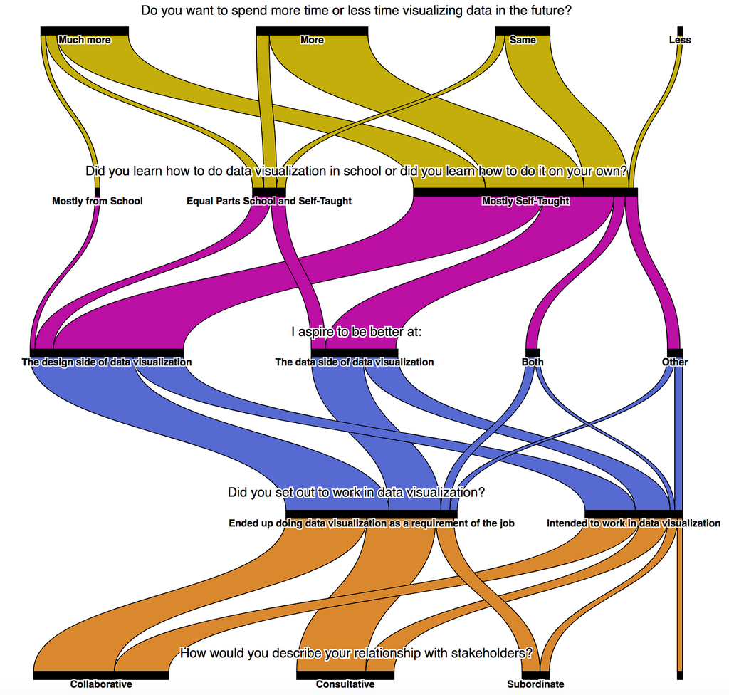

- THE WORK OF EDWARD TUFTE AND GRAPHICS PRESS

https://www.edwardtufte.com/tufte/

- R Graph Gallery

https://www.r-graph-gallery.com/

- rollApp

https://www.rollapp.com/apps/statistics

- Bluesky Statistics

http://www.blueskystatistics.com/

- Knime

https://www.knime.com/

- **R commander**

http://www.rcommander.com/

- Free statistics software for Macintosh computers (Macs) https://www.macstats.org/statistics-software/free.html
- ggplot2 extensions

http://www.ggplot2-exts.org/gallery/

- Web Pages that Perform Statistical Calculations

http://statpages.info/

- EpiTools epidemiological calculators

http://epitools.ausvet.com.au/content.php?page=home

- QuickCalcs Online Statistical Calculator

https://www.graphpad.com/quickcalcs/

- VassarStats: Website for Statistical Computation http://vassarstats.net/
- Cutoff Finder http://molpath.charite.de/cutoff/index.jsp
- Plotly

https://plot.ly/

https://plot.ly/r/

- A website trying to present all relevant data visualizations, so you can find the right visualization and get inspiration on how to do it.

http://datavizproject.com/

- Open Source Epidemiologic Statistics for Public Health

http://www.openepi.com/

- https://www.datawrapper.de
- https://public.tableau.com/
- **Open Refine, Google Refine**

http://openrefine.org/

- Google Refine 2.0 - Introduction (1 of 3) (video version 2)

https://www.youtube.com/watch?v=B70J_H_zAWM

- Google Refine 2.0 - Data Augmentation (3 of 3) (video version 2)

https://www.youtube.com/watch?v=5tsyz3ibYzk&index=2&list=WL

- https://www.coursera.org/learn/datavisualization/supplement/ijZAO/resources

**Online Data Visualization Websites**

- [DataHero](http://datahero.com)
- [Plotly](http://plot.ly)
- [Number Picture](http://site.numberpicture.com)
- Polychart
- [Juice Analytics](http://www.juiceanalytics.com)
- [Weave](http://www.iweave.org)
- [Datavisual](http://datavisu.al)
- [Silk](https://www.silk.co)
- [Zoomdata](http://www.zoomdata.com) (via the cloud platforms)
- [RAW](http://app.raw.densitydesign.org)
- [Datawrapper](https://datawrapper.de)

**Software**

- [Tableau](http://www.tableau.com)
- [SAP Lumira](http://www.sapstore.com/getlumira) (including a free Personal Edition version)
- [Microsoft Excel](https://products.office.com/excel) (or any other spreadsheet that includes charts)
- [ClearStory](http://www.clearstorydata.com)
- [BeyondCore](http://beyondcore.com)
- [Mathematica](http://www.wolfram.com/mathematica/)
- [MATLAB](http://www.mathworks.com/products/matlab/)
- [MatPlotLib](http://matplotlib.org) (if you are comfortable programming Python)
- [R Programming Language](https://www.r-project.org)
- [ggplot2](http://ggplot2.org)

**Some Data Sources**

- [Google Public Data Explorer](http://www.google.com/publicdata/directory)
- [Data from the World Bank](http://data.worldbank.org)

**Plotting your data**

https://sites.google.com/site/obintlab/wiki/plotting-data

- RevMan 5

http://community.cochrane.org/tools/review-production-tools/revman-5

- Trifacta

https://www.trifacta.com/

- UW Interactive Data Lab

http://idl.cs.washington.edu/

https://vega.github.io/

- Design better data tables The ingredients of a successful data table UI

https://uxdesign.cc/design-better-data-tables-4ecc99d23356

- gapminder

https://www.gapminder.org/

- DOLLAR STREET

https://www.gapminder.org/dollar-street/matrix

- Show your own data

https://vizabi.org/tutorials/2017/04/03/show-your-data/

- Join your data with Gapminder’s data

https://vizabi.org/tutorials/2017/04/04/join-your-data-with-g/

- Sankey diagram

https://medium.com/@Elijah_Meeks/2018-data-visualization-survey-results-26a90856476b

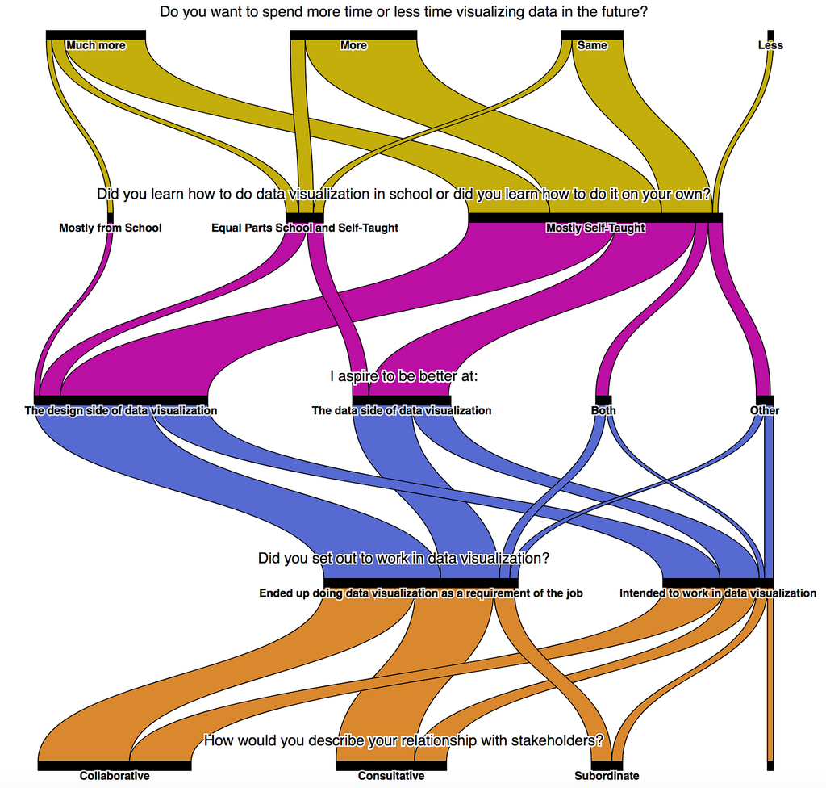

- THE WORK OF EDWARD TUFTE AND GRAPHICS PRESS

https://www.edwardtufte.com/tufte/

- R Graph Gallery

https://www.r-graph-gallery.com/

- rollApp

https://www.rollapp.com/apps/statistics

- Bluesky Statistics

http://www.blueskystatistics.com/

- Knime

https://www.knime.com/

- **R commander**

http://www.rcommander.com/

- Free statistics software for Macintosh computers (Macs) https://www.macstats.org/statistics-software/free.html
- ggplot2 extensions

http://www.ggplot2-exts.org/gallery/

- Web Pages that Perform Statistical Calculations

http://statpages.info/

- EpiTools epidemiological calculators

http://epitools.ausvet.com.au/content.php?page=home

- QuickCalcs Online Statistical Calculator

https://www.graphpad.com/quickcalcs/

- VassarStats: Website for Statistical Computation http://vassarstats.net/
- Cutoff Finder http://molpath.charite.de/cutoff/index.jsp
- Plotly

https://plot.ly/

https://plot.ly/r/

- A website trying to present all relevant data visualizations, so you can find the right visualization and get inspiration on how to do it.

http://datavizproject.com/

- Open Source Epidemiologic Statistics for Public Health

http://www.openepi.com/

- https://www.datawrapper.de
- https://public.tableau.com/
- **Open Refine, Google Refine**

http://openrefine.org/

- Google Refine 2.0 - Introduction (1 of 3) (video version 2)

https://www.youtube.com/watch?v=B70J_H_zAWM

- Google Refine 2.0 - Data Augmentation (3 of 3) (video version 2)

https://www.youtube.com/watch?v=5tsyz3ibYzk&index=2&list=WL

- https://www.coursera.org/learn/datavisualization/supplement/ijZAO/resources

**Online Data Visualization Websites**

- [DataHero](http://datahero.com)
- [Plotly](http://plot.ly)
- [Number Picture](http://site.numberpicture.com)
- Polychart
- [Juice Analytics](http://www.juiceanalytics.com)
- [Weave](http://www.iweave.org)
- [Datavisual](http://datavisu.al)
- [Silk](https://www.silk.co)
- [Zoomdata](http://www.zoomdata.com) (via the cloud platforms)
- [RAW](http://app.raw.densitydesign.org)
- [Datawrapper](https://datawrapper.de)

**Software**

- [Tableau](http://www.tableau.com)
- [SAP Lumira](http://www.sapstore.com/getlumira) (including a free Personal Edition version)
- [Microsoft Excel](https://products.office.com/excel) (or any other spreadsheet that includes charts)
- [ClearStory](http://www.clearstorydata.com)
- [BeyondCore](http://beyondcore.com)
- [Mathematica](http://www.wolfram.com/mathematica/)
- [MATLAB](http://www.mathworks.com/products/matlab/)
- [MatPlotLib](http://matplotlib.org) (if you are comfortable programming Python)
- [R Programming Language](https://www.r-project.org)
- [ggplot2](http://ggplot2.org)

**Some Data Sources**

- [Google Public Data Explorer](http://www.google.com/publicdata/directory)
- [Data from the World Bank](http://data.worldbank.org)

**Plotting your data**

https://sites.google.com/site/obintlab/wiki/plotting-data

- RevMan 5

http://community.cochrane.org/tools/review-production-tools/revman-5

- Trifacta

https://www.trifacta.com/

- UW Interactive Data Lab

http://idl.cs.washington.edu/

https://vega.github.io/

- Design better data tables The ingredients of a successful data table UI

https://uxdesign.cc/design-better-data-tables-4ecc99d23356

- gapminder

https://www.gapminder.org/

- DOLLAR STREET

https://www.gapminder.org/dollar-street/matrix

- Show your own data

https://vizabi.org/tutorials/2017/04/03/show-your-data/

- Join your data with Gapminder’s data

https://vizabi.org/tutorials/2017/04/04/join-your-data-with-g/